# DATA 607 Project 2

Tidying and Tansforming Data

Donny Lofland

10/6/2019

```r
knitr::opts_chunk$set(echo=TRUE, message=FALSE, warning=FALSE, include=TRUE, error=FALSE)
library(tidyverse)
library(RMySQL)      # Older MysQL library (note: I could NOT get the RMariaDB lib to work)
library(formattable) # Pretty print tables
library(xlsx)
library(rvest)
library(stargazer)
```

Source files: https://github.com/djlofland/DATA607_F2019/tree/master/Project2

## Assignment

The goal of this assignment is to give you practice in preparing different datasets for downstream analysis work. Your task is to:

1. Choose any three of the “wide” datasets identified in the Week 6 Discussion items. (You may use your own dataset; please don’t use my Sample Post dataset, since that was used in your Week 6 assignment!) For each of the three chosen datasets:
- Create a .CSV file (or optionally, a MySQL database!) that includes all of the information included in the dataset. You’re encouraged to use a “wide” structure similar to how the information appears in the discussion item, so that you can practice tidying and transformations as described below.
- Read the information from your .CSV file into R, and use tidyr and dplyr as needed to tidy and transform your data. [Most of your grade will be based on this step!]
- Perform the analysis requested in the discussion item.
- Your code should be in an R Markdown file, posted to rpubs.com, and should include narrative descriptions of your data cleanup work, analysis, and conclusions.
2. Please include in your homework submission, for each of the three chosen datasets:
- The URL to the .Rmd file in your GitHub repository, and
- The URL for your rpubs.com web page.

## Project

In the late 1990’s I worked for an NGO that focused on training doctors, nurses and midwives on women’s reproductive health issues and health during pregancy. The NGO developed and tested training programs in very rural areas around the world to teach health care providers how to provide care for women with no easy access to primary health care facilities or doctors.

In our Weekly Discussion forum, Euclid Zhang shared a link to UNICEF data and while browsing their datasets, I stumbled on a few datasets which really spoke to me and the incredible work I once contributed toward. The datasets provide data and trends in both maternal health and outcomes along with indicators by country. For Project 2, rather than pick 3 disparate datasets to analyze, I’m going to instead follow this theme of maternal outcome around the world.

For an understanding of the problem space, see [Maternal mortality](https://www.who.int/news-room/fact-sheets/detail/maternal-mortality).

Some key facts they provide: - Every day in 2017, approximately 810 women died from preventable causes related to pregnancy and childbirth. - Between 2000 and 2017, the maternal mortality ratio (MMR, number of maternal deaths per 100,000 live births) dropped by about 38% worldwide. - 94% of all maternal deaths occur in low and lower middle-income countries. - Young adolescents (ages 10-14) face a higher risk of complications and death as a result of pregnancy than other women. - Skilled care before, during and after childbirth can save the lives of women and newborns.

The primary datasets I’ll explore are:

- [Trends in estimates of maternal mortality ratio (maternal deaths per 100,000 live births) 2000-2017 (September 2019)](https://data.unicef.org/wp-content/uploads/2015/11/MMR-trend-estimates-2000-2017_MMEIG-2.xlsx)
- [All adolescents maternal health indicators (July 2018)](https://data.unicef.org/wp-content/uploads/2018/07/maternal_health_adolescents_indicators_April-2016_250d599.xlsx)
- [WHO Health Expenditures by Country](http://apps.who.int/nha/database/ViewData/Indicators/en)
- [Birthrate Data by Country](http://api.worldbank.org/v2/en/indicator/SP.DYN.CBRT.IN?downloadformat=excel)
- List_of_countries_by_past_and_future_population

Each of these datasets required Tidy processing to clean up. I also join the data where possible by country and year to tease out additional patterns not available within any one dataset.

To facilitate joining tables using different Country label conventions, I scraped a lookup table with Country names and ISO3 codes which I join to my various datasets.

- [World ISO3 Country Codes](https://www.iban.com/country-codes)

These datasets explore different years, but have broad overlap between 2000-2015 (every 5 years). My analysis will be somewhat limited by the available data. If I were doing a deeper dive, I would look for more complete data and/or limit my questions to those countries that have a richer set of data. My guess is that better data may indicate more attention to tackling problems with maternal mortality and as a consequence, better data might come from countries with better reporting and more on-the-ground efforts.

## Load Data

### Load Country Codes

During research I found that different datasets included ISO2 (Alpha 2), ISO3 (Alpha 3) and/or descriptive country names. Just in case it’s needed, I wanted a lookup table I can use to join different datasets using different country name conventions.

```r
url             <- "https://www.iban.com/country-codes"
cache_fn        <- 'country_codes.csv'

isCacheFound    <- FALSE
local_cache_fn  <- paste('data/cache/', cache_fn, sep = '')

# Check if we have a local copy of the data available to load
if(file.exists(local_cache_fn)) {
  msg <- paste('Found cached copy: ', local_cache_fn, sep='')
  isCacheFound <- TRUE
}

# Cached ata file found
if (isCacheFound) {
  # Load CSV Files
  data_df <- read_csv(local_cache_fn, col_names = TRUE)
  isDataLoaded <- TRUE
  msg <- 'Cached CSV data loaded.'

} else {
  # Load Raw Data
  data_df <- url %>%
    xml2::read_html() %>%
    html_nodes(xpath='//*[@id="myTable"]') %>%
    html_table()

  data_df <- data_df[[1]]

  # Cache the processed as CSV for future
  write.csv(data_df, local_cache_fn, row.names=FALSE, na="")
}

iso3_codes <- data_df
isTidy_iso3_codes <- FALSE

print(msg)
```

```
## [1] "Cached CSV data loaded."
```

```r
knitr::kable(iso3_codes[1:10, ], booktabs = T, caption = "ISO2 and ISO3 Country Codes.  Raw data, first 10 rows shown.  (Source: http://iban.com/country-codes)")
```

ISO2 and ISO3 Country Codes. Raw data, first 10 rows shown. (Source: http://iban.com/country-codes)

| Country | Alpha-2 code | Alpha-3 code | Numeric |
| --- | --- | --- | --- |
| Afghanistan | AF | AFG | 4 |
| Åland Islands | AX | ALA | 248 |
| Albania | AL | ALB | 8 |
| Algeria | DZ | DZA | 12 |
| American Samoa | AS | ASM | 16 |
| Andorra | AD | AND | 20 |
| Angola | AO | AGO | 24 |
| Anguilla | AI | AIA | 660 |
| Antarctica | AQ | ATA | 10 |
| Antigua and Barbuda | AG | ATG | 28 |

#### Tidy Country Codes

```r
# If rerunning our RMarkdown, only tidy if necessary
if (isTidy_iso3_codes == FALSE) {

  # Convert year columns into a variable
  iso3_codes <- iso3_codes %>%
    mutate(ISO3 = `Alpha-3 code`, ISO2 = `Alpha-2 code`) %>%
    select(Country, ISO3, ISO2)

  isTidy_iso3_codes <- TRUE # if this cell ir rerun, don't try to re-tidy

} else {
  print('Already processed, nothing to do.')
}
```

```r
knitr::kable(iso3_codes[1:10, ], booktabs = T, caption = "ISO2 and ISO3 Country Codes.  Tidy data, first 10 rows shown.")
```

ISO2 and ISO3 Country Codes. Tidy data, first 10 rows shown.

| Country | ISO3 | ISO2 |
| --- | --- | --- |
| Afghanistan | AFG | AF |
| Åland Islands | ALA | AX |
| Albania | ALB | AL |
| Algeria | DZA | DZ |
| American Samoa | ASM | AS |
| Andorra | AND | AD |
| Angola | AGO | AO |
| Anguilla | AIA | AI |
| Antarctica | ATA | AQ |
| Antigua and Barbuda | ATG | AG |

### Load Population Data

Changes in country population might change how we interpret maternal mortality rate. While the rate should theoretically be independent from population (by definition MMR is maternal deaths per 100,000 live births), if there is a large increase or decrease in population, this might impact conditions around pregnency (nutrition, access to health care, etc) and/or conditions at time of birth (e.g. access to health care). Since MMR is “deaths per live briths”, I’ll end up needing population data to help calculate the number of live births.

```r
url        <- "https://en.wikipedia.org/wiki/List_of_countries_by_past_and_future_population"
cache_fn   <- 'population.csv'

isCacheFound <- FALSE
local_cache_fn    <- paste('data/cache/', cache_fn, sep = '')

# Check if we have a local copy of the data available to load
if(file.exists(local_cache_fn)) {
  msg <- paste('Found cached copy: ', local_cache_fn, sep='')
  isCacheFound <- TRUE
}

# Cached ata file found
if (isCacheFound) {
  # Load CSV Files
  data_df <- read_csv(local_cache_fn, col_names = TRUE)
  isDataLoaded <- TRUE
  msg <- 'Cached CSV data loaded.'

} else {
  # Load Raw Data
  data_df <- url %>%
    xml2::read_html() %>%
    html_nodes(xpath='//*[@id="mw-content-text"]/div/table[2]') %>%
    html_table()

  data_df <- data_df[[1]]

  # Cache the processed as CSV for future
  write.csv(data_df, local_cache_fn, row.names=FALSE, na="")
}

population_df <- data_df
isTidy_population <- FALSE

print(msg)
```

```
## [1] "Cached CSV data loaded."
```

```r
knitr::kable(population_df[1:10, ], booktabs = T, caption = "Population Data.  Raw data, first 10 rows shown.  (Source: https://en.wikipedia.org/wiki/List_of_countries_by_past_and_future_population)")
```

Population Data. Raw data, first 10 rows shown. (Source: https://en.wikipedia.org/wiki/List_of_countries_by_past_and_future_population)

| Country (or dependent territory) | 1985 | % | 1990 | %_1 | 1995 | %_2 | 2000 | %_3 | 2005 | %_4 | 2010 | %_5 | 2015 | %_6 |
| --- | --- | --- | --- | --- | --- | --- | --- | --- | --- | --- | --- | --- | --- | --- |
| Afghanistan | 13120 | -2.70 | 13569 | 0.67 | 19446 | 7.46 | 22462 | 2.93 | 26335 | 3.23 | 29121 | 2.03 | 32565 | 2.26 |
| Albania | 2957 | 2.05 | 3245 | 1.88 | 3159 | -0.54 | 3159 | 0.00 | 3025 | -0.86 | 2987 | -0.25 | 3030 | 0.28 |
| Algeria | 22009 | 3.19 | 25191 | 2.74 | 28322 | 2.37 | 30639 | 1.58 | 32918 | 1.45 | 35950 | 1.78 | 39543 | 1.92 |
| American Samoa | 39 | 3.57 | 48 | 4.09 | 54 | 2.69 | 58 | 1.39 | 57 | -0.28 | 56 | -0.53 | 55 | -0.41 |
| Andorra | 45 | 5.84 | 53 | 3.41 | 64 | 3.70 | 66 | 0.58 | 77 | 3.18 | 85 | 2.12 | 86 | 0.25 |
| Angola | 8390 | 3.09 | 9486 | 2.48 | 11000 | 3.01 | 12683 | 2.89 | 14770 | 3.09 | 17043 | 2.90 | 19626 | 2.86 |
| Anguilla | 7 | 1.35 | 9 | 3.84 | 10 | 3.20 | 12 | 3.02 | 14 | 2.80 | 15 | 2.40 | 17 | 2.14 |
| Antigua and Barbuda | 65 | -1.24 | 65 | -0.07 | 69 | 1.38 | 76 | 1.86 | 82 | 1.53 | 87 | 1.31 | 93 | 1.28 |
| Argentina | 30672 | 1.57 | 33036 | 1.50 | 35274 | 1.32 | 37336 | 1.14 | 39182 | 0.97 | 41344 | 1.08 | 43432 | 0.99 |
| Armenia | 3465 | 2.02 | 3530 | 0.37 | 3131 | -2.37 | 3101 | -0.19 | 3085 | -0.10 | 3072 | -0.08 | 3057 | -0.10 |

#### Tidy Population Data

```r
# If rerunning our RMarkdown, only tidy if necessary
if (isTidy_population == FALSE) {

  # Convert year columns into a variable
  population_df <- population_df %>%
    mutate(Country = `Country (or dependent territory)`) %>%
    select(Country, `2000`, `2005`, `2010`, `2015`) %>%
    gather(Year, Population, -Country)

  # Fix datatypes
  population_df$Year <- as.numeric(population_df$Year)

  # Filter years
  population_df <- population_df %>% filter(Year >= 2000 & Year <= 2015) %>% arrange(Country, Year)
  population_df$Population <- population_df$Population* 1000
  population_df <- population_df %>% left_join(iso3_codes)

  isTidy_population <- TRUE # if this cell ir rerun, don't try to re-tidy

} else {
  print('Already processed, nothing to do.')
}
```

```r
knitr::kable(population_df[1:10, ], booktabs = T, caption = "Population Data.  Tidy date, first 10 rows shown.")
```

Population Data. Tidy date, first 10 rows shown.

| Country | Year | Population | ISO3 | ISO2 |
| --- | --- | --- | --- | --- |
| Afghanistan | 2000 | 22462000 | AFG | AF |
| Afghanistan | 2005 | 26335000 | AFG | AF |
| Afghanistan | 2010 | 29121000 | AFG | AF |
| Afghanistan | 2015 | 32565000 | AFG | AF |
| Albania | 2000 | 3159000 | ALB | AL |
| Albania | 2005 | 3025000 | ALB | AL |
| Albania | 2010 | 2987000 | ALB | AL |
| Albania | 2015 | 3030000 | ALB | AL |
| Algeria | 2000 | 30639000 | DZA | DZ |
| Algeria | 2005 | 32918000 | DZA | DZ |

### Load Birthrate Data

While there is variation between countries, the overall birthrate worldwide has declined. To understand changes in maternal mortality, we will need to estimate how many births are occuring during years of interest in each country. It’s possible that changes in birth rates could have an impact on MMR.

```r
# We first want to check if the data has already been loaded and muched  as a local cached .csv file.  If the csv file is available, use that.  If
# it's not, then we will download and/or load the raw data, munge and save as a local cache .csv.

# Source Data File
source_url        <- 'http://api.worldbank.org/v2/en/indicator/SP.DYN.CBRT.IN?downloadformat=excel'
raw_fn            <- 'API_SP.DYN.CBRT.IN_DS2_en_excel_v2_248743.xlsx'
cache_fn          <- 'births.csv'

# Which WorkSheet to load and there are some extra rows above & below our table of interest.
data_header_rows  <- 3  # rows at top to skip (note, blank rows are automatically skipped)
data_tail_rows    <- 0  # rows at bottom to skip
data_header       <- FALSE
data_sheet        <- 1      # optional for Excel Workbooks
data_column_names <- c('Country', 'ISO3', 'Indicator', 'Indicator_Code', as.character(seq(1960, 2017, 1)))

# Some variables to help with flow control
isCacheFound      <- FALSE
isRawFound        <- FALSE
isDataLoaded      <- FALSE

local_raw_fn      <- paste('data/raw/', raw_fn, sep = '')
local_cache_fn    <- paste('data/cache/', cache_fn, sep = '')

# Check if we have a local copy of the data available to load
if(file.exists(local_cache_fn)) {
  msg <- paste('Found cached copy: ', local_cache_fn, sep='')
  isCacheFound <- TRUE

} else if(file.exists(local_raw_fn)) {
  msg <- paste('Found raw copy: ', local_raw_fn, ' (May need processing)', sep = '')
  isRawFound <- TRUE

} else {
  # Attempt to download the dataset
  download.file(source_url, local_raw_fn, method="auto")

  if(file.size(local_raw_fn) > 0) {
    msg <- paste('Downloaded file from: ', source_url, sep='')
    isRawFound <- TRUE
  } else {
    msg <- paste("File not found and couldn't be downloaded. Check file name and/or source.")
  }
}

print(msg)
```

```
## [1] "Found cached copy: data/cache/births.csv"
```

```r
# Cached data file found
if (isCacheFound) {
  # Load CSV Files
  data_df <- read_csv(paste('data/cache/', cache_fn, sep = ''), col_names = TRUE)
  isDataLoaded <- TRUE
  msg <- 'Cached CSV data loaded.'

} else if (isRawFound) {
  # Load Raw File - Make sure it's excel since read.xlsx will break with other file formats
  if (str_detect(local_raw_fn, '.*\\.xlsx?$')) {
    data_df <- read.xlsx(local_raw_fn, sheetIndex = data_sheet, header=data_header)
    isDataLoaded <- TRUE
    msg <- 'Raw data loaded.'

    ##### DATA PROCESSING start #####

    # Are there any extraneous row at to top to remove?
    if (data_header_rows > 0) {
      data_df <- data_df[(data_header_rows + 1):nrow(data_df),]
      data_header_rows <- 0
      rownames(data_df) <- NULL
    }

    # Did the raw file have any extraneous rows at the bottom to remove?
    if (data_tail_rows > 0) {
      last_row <- nrow(data_df)-data_tail_rows
      data_df <- data_df[0:last_row,]
      data_tail_rows <- 0
      rownames(data_df) <- NULL
    }

    # Remove any empty columns in the raw data
    data_df <- data_df %>% select_if(function(x) {!all(is.na(x))})

    # Set the Column names
    if (length(data_column_names) > 0) {
      names(data_df) <- data_column_names
      data_column_names <- list()
    }

    # Convert to a tibble
    data_df <- as_tibble(data_df)

    ##### DATA PROCESSING done #####

    # Cache the processed as CSV for future
    write.csv(data_df, local_cache_fn, row.names=FALSE, na="")
    msg <- 'Raw data loaded, processed and saved to cache.'

    data_df <- read_csv(paste('data/cache/', cache_fn, sep = ''), col_names = TRUE)
  }
} else {
  # Bummer - no load data file was found to load
  msg <- 'Data NOT loaded.'
}

birthrate_df   <- data_df
isTidy_birthrate <- FALSE

print(msg)
```

```
## [1] "Cached CSV data loaded."
```

```r
knitr::kable(birthrate_df[1:10, ], booktabs = T, caption = "Birthrate Data.  Raw data, first 10 rows shown.  Births per 1000 people.  (Source: http://api.worldbank.org/v2/en/indicator/SP.DYN.CBRT.IN?downloadformat=csv)")
```

Birthrate Data. Raw data, first 10 rows shown. Births per 1000 people. (Source: http://api.worldbank.org/v2/en/indicator/SP.DYN.CBRT.IN?downloadformat=csv)

| Country | ISO3 | Indicator | Indicator_Code | 1960 | 1961 | 1962 | 1963 | 1964 | 1965 | 1966 | 1967 | 1968 | 1969 | 1970 | 1971 | 1972 | 1973 | 1974 | 1975 | 1976 | 1977 | 1978 | 1979 | 1980 | 1981 | 1982 | 1983 | 1984 | 1985 | … |
| --- | --- | --- | --- | --- | --- | --- | --- | --- | --- | --- | --- | --- | --- | --- | --- | --- | --- | --- | --- | --- | --- | --- | --- | --- | --- | --- | --- | --- | --- | --- |
| Aruba | ABW | Birth rate, crude (per 1,000 people) | SP.DYN.CBRT.IN | 35.67900 | 34.52900 | 33.3200 | 32.05000 | 30.73700 | 29.4130 | 28.12100 | 26.90800 | 25.81700 | 24.87200 | 24.09900 | 23.50500 | 23.06800 | 22.76000 | 22.56100 | 22.45200 | 22.41400 | 22.4240 | 22.45400 | 22.47800 | 22.47200 | 22.42400 | 22.32900 | 22.18700 | 21.98900 | 21.72600 | … |
| Afghanistan | AFG | Birth rate, crude (per 1,000 people) | SP.DYN.CBRT.IN | 51.27900 | 51.37300 | 51.4570 | 51.53000 | 51.58900 | 51.6310 | 51.65200 | 51.65000 | 51.62300 | 51.57400 | 51.50200 | 51.41100 | 51.30300 | 51.18400 | 51.05800 | 50.93000 | 50.80300 | 50.6780 | 50.55500 | 50.43600 | 50.32100 | 50.21000 | 50.09800 | 49.98400 | 49.86500 | 49.73500 | … |
| Angola | AGO | Birth rate, crude (per 1,000 people) | SP.DYN.CBRT.IN | 49.08000 | 48.77900 | 48.5470 | 48.43000 | 48.45000 | 48.6220 | 48.93600 | 49.34300 | 49.78700 | 50.23100 | 50.61900 | 50.90300 | 51.06200 | 51.09400 | 51.00500 | 50.82500 | 50.60000 | 50.3860 | 50.22600 | 50.13900 | 50.13400 | 50.20700 | 50.32200 | 50.44900 | 50.56900 | 50.66300 | … |
| Albania | ALB | Birth rate, crude (per 1,000 people) | SP.DYN.CBRT.IN | 40.92400 | 40.36800 | 39.6270 | 38.72300 | 37.69500 | 36.5990 | 35.49600 | 34.43500 | 33.45800 | 32.59000 | 31.83700 | 31.18300 | 30.58700 | 30.01900 | 29.47300 | 28.94900 | 28.45500 | 28.0040 | 27.60600 | 27.26200 | 26.98100 | 26.77200 | 26.62700 | 26.52800 | 26.45200 | 26.36700 | … |
| Andorra | AND | Birth rate, crude (per 1,000 people) | SP.DYN.CBRT.IN | NA | NA | NA | NA | NA | NA | NA | NA | NA | NA | NA | NA | NA | NA | NA | NA | NA | NA | NA | NA | NA | NA | NA | NA | NA | NA | … |
| Arab World | ARB | Birth rate, crude (per 1,000 people) | SP.DYN.CBRT.IN | 47.79008 | 47.55839 | 47.3276 | 47.09162 | 46.84421 | 46.5771 | 46.28291 | 45.96055 | 45.61137 | 45.23716 | 44.84362 | 44.44035 | 44.03865 | 43.64783 | 43.27485 | 42.92493 | 42.60063 | 42.2929 | 41.98992 | 41.68051 | 41.34983 | 40.98353 | 40.57024 | 40.10007 | 39.56784 | 38.96898 | … |
| United Arab Emirates | ARE | Birth rate, crude (per 1,000 people) | SP.DYN.CBRT.IN | 47.26600 | 46.70500 | 46.0930 | 45.42600 | 44.69400 | 43.8560 | 42.85700 | 41.67800 | 40.32900 | 38.84300 | 37.27600 | 35.69500 | 34.17900 | 32.80400 | 31.62500 | 30.70300 | 30.08200 | 29.7350 | 29.61100 | 29.66600 | 29.83900 | 30.05900 | 30.25100 | 30.34300 | 30.28200 | 30.02200 | … |
| Argentina | ARG | Birth rate, crude (per 1,000 people) | SP.DYN.CBRT.IN | 23.77500 | 23.56900 | 23.3720 | 23.19100 | 23.03300 | 22.9090 | 22.83000 | 22.80400 | 22.83400 | 22.92400 | 23.09000 | 23.35000 | 23.69500 | 24.09800 | 24.52400 | 24.91200 | 25.19100 | 25.3200 | 25.27700 | 25.06600 | 24.71800 | 24.28800 | 23.84600 | 23.45100 | 23.12800 | 22.88900 | … |
| Armenia | ARM | Birth rate, crude (per 1,000 people) | SP.DYN.CBRT.IN | 38.50900 | 37.21700 | 35.5610 | 33.62900 | 31.54000 | 29.4470 | 27.49600 | 25.78600 | 24.38900 | 23.35500 | 22.69400 | 22.36600 | 22.26200 | 22.28300 | 22.38200 | 22.53000 | 22.72100 | 22.9610 | 23.24300 | 23.53800 | 23.82300 | 24.08200 | 24.29700 | 24.44600 | 24.50200 | 24.43100 | … |
| American Samoa | ASM | Birth rate, crude (per 1,000 people) | SP.DYN.CBRT.IN | NA | NA | NA | NA | NA | NA | NA | NA | NA | NA | NA | NA | NA | NA | NA | NA | NA | NA | NA | NA | NA | NA | NA | NA | NA | NA | … |

#### Tidy Birthrate Data

```r
# If rerunning our RMarkdown, only tidy if necessary
if (isTidy_birthrate == FALSE) {

  # Convert year columns into a variable
  birthrate_df <- birthrate_df %>%
    select(Country, `2000`, `2005`, `2010`, `2015`) %>%
    gather(Year, BirthRate, -Country) %>%
    arrange(Country, Year) %>%
    inner_join(iso3_codes)

  # Fix datatypes
  birthrate_df$Year <- as.numeric(birthrate_df$Year)

  isTidy_birthrate <- TRUE # if this cell ir rerun, don't try to re-tidy

} else {
  print('Already processed, nothing to do.')
}
```

```r
knitr::kable(birthrate_df[1:10, ], booktabs = T, caption = "Birthrate Data.  Tidy data, first 10 rows shown.  Births per 1000 people.")
```

Birthrate Data. Tidy data, first 10 rows shown. Births per 1000 people.

| Country | Year | BirthRate | ISO3 | ISO2 |
| --- | --- | --- | --- | --- |
| Afghanistan | 2000 | 48.021 | AFG | AF |
| Afghanistan | 2005 | 44.723 | AFG | AF |
| Afghanistan | 2010 | 39.829 | AFG | AF |
| Afghanistan | 2015 | 34.809 | AFG | AF |
| Albania | 2000 | 16.436 | ALB | AL |
| Albania | 2005 | 12.821 | ALB | AL |
| Albania | 2010 | 12.001 | ALB | AL |
| Albania | 2015 | 12.197 | ALB | AL |
| Algeria | 2000 | 19.554 | DZA | DZ |
| Algeria | 2005 | 20.774 | DZA | DZ |

### Load Maternal Mortality Data

THis is the primary dataset which everything else is linked with. Here we see the maternal mortality rate provided as deaths per 100,000 live births broken out by country and year.

```r
# We first want to check if the data has already been loaded and muched  as a local cached .csv file.  If the csv file is available, use that.  If
# it's not, then we will download and/or load the raw data, munge and save as a local cache .csv.

# Source Data File
source_url        <- 'https://data.unicef.org/wp-content/uploads/2015/11/MMR-trend-estimates-2000-2017_MMEIG-2.xlsx'
raw_fn            <- 'MMR-trend-estimates-2000-2017_MMEIG-2.xlsx'
cache_fn          <- 'mmr_data.csv'

# Which WorkSheet to load and there are some extra rows above & below our table of interest.
data_header_rows  <- 4  # rows at top to skip (note, blank rows are automatically skipped)
data_tail_rows    <- 17  # rows at bottom to skip
data_header       <- FALSE
data_sheet        <- 1      # optional for Excel Workbooks
data_column_names <- c('ISO3','Country','2000','2005','2010','2015', '2017')

# Some variables to help with flow control
isCacheFound      <- FALSE
isRawFound        <- FALSE
isDataLoaded      <- FALSE

local_raw_fn      <- paste('data/raw/', raw_fn, sep = '')
local_cache_fn    <- paste('data/cache/', cache_fn, sep = '')

# Check if we have a local copy of the data available to load
if(file.exists(local_cache_fn)) {
  msg <- paste('Found cached copy: ', local_cache_fn, sep='')
  isCacheFound <- TRUE

} else if(file.exists(local_raw_fn)) {
  msg <- paste('Found raw copy: ', local_raw_fn, ' (May need processing)', sep = '')
  isRawFound <- TRUE

} else {
  # Attempt to download the dataset
  download.file(source_url, local_raw_fn, method="auto")

  if(file.size(local_raw_fn) > 0) {
    msg <- paste('Downloaded file from: ', source_url, sep='')
    isRawFound <- TRUE
  } else {
    msg <- paste("File not found and couldn't be downloaded. Check file name and/or source.")
  }
}

print(msg)
```

```
## [1] "Found cached copy: data/cache/mmr_data.csv"
```

```r
# Cached data file found
if (isCacheFound) {
  # Load CSV Files
  data_df <- read_csv(paste('data/cache/', cache_fn, sep = ''), col_names = TRUE)
  isDataLoaded <- TRUE
  msg <- 'Cached CSV data loaded.'

} else if (isRawFound) {
  # Load Raw File - Make sure it's excel since read.xlsx will break with other file formats
  if (str_detect(local_raw_fn, '.*\\.xlsx?$')) {
    data_df <- read.xlsx(local_raw_fn, sheetIndex = data_sheet, header=data_header)
    isDataLoaded <- TRUE
    msg <- 'Raw data loaded.'

    ##### DATA PROCESSING start #####

    # Are there any extraneous row at to top to remove?
    if (data_header_rows > 0) {
      data_df <- data_df[(data_header_rows + 1):nrow(data_df),]
      data_header_rows <- 0
      rownames(data_df) <- NULL
    }

    # Did the raw file have any extraneous rows at the bottom to remove?
    if (data_tail_rows > 0) {
      last_row <- nrow(data_df)-data_tail_rows
      data_df <- data_df[0:last_row,]
      data_tail_rows <- 0
      rownames(data_df) <- NULL
    }

    # Remove any empty columns in the raw data
    data_df <- data_df %>% select_if(function(x) {!all(is.na(x))})

    # Set the Column names
    if (length(data_column_names) > 0) {
      names(data_df) <- data_column_names
      data_column_names <- list()
    }

    # Convert to a tibble
    data_df <- as_tibble(data_df)

    ##### DATA PROCESSING done #####

    # Cache the processed as CSV for future
    write.csv(data_df, local_cache_fn, row.names=FALSE, na="")
    msg <- 'Raw data loaded, processed and saved to cache.'

    data_df <- read_csv(paste('data/cache/', cache_fn, sep = ''), col_names = TRUE)
  }
} else {
  # Bummer - no load data file was found to load
  msg <- 'Data NOT loaded.'
}

mmr_df <- data_df
isTidy_mmr   <- FALSE

print(msg)
```

```
## [1] "Cached CSV data loaded."
```

```r
knitr::kable(mmr_df[1:10, ], booktabs = T, caption = "Maternal Mortality Data.  Count of maternal deaths per 100,000 live births.  Raw data, first 10 rows shown.  (Source: https://data.unicef.org/resources/dataset/maternal-health-data/)")
```

Maternal Mortality Data. Count of maternal deaths per 100,000 live births. Raw data, first 10 rows shown. (Source: https://data.unicef.org/resources/dataset/maternal-health-data/)

| ISO3 | Country | 2000 | 2005 | 2010 | 2015 | 2017 |
| --- | --- | --- | --- | --- | --- | --- |
| AFG | Afghanistan | 1450 | 1140 | 954 | 701 | 638 |
| ALB | Albania | 23 | 22 | 21 | 15 | 15 |
| DZA | Algeria | 161 | 127 | 115 | 114 | 112 |
| AGO | Angola | 827 | 519 | 326 | 251 | 241 |
| ATG | Antigua and Barbuda | 44 | 40 | 44 | 43 | 42 |
| ARG | Argentina | 66 | 59 | 51 | 41 | 39 |
| ARM | Armenia | 43 | 35 | 32 | 28 | 26 |
| AUS | Australia | 7 | 5 | 5 | 6 | 6 |
| AUT | Austria | 6 | 6 | 5 | 5 | 5 |
| AZE | Azerbaijan | 47 | 42 | 31 | 27 | 26 |

#### Tidy MMR Dataset

```r
# If rerunning our RMarkdown, only tidy if necessary
if (isTidy_mmr == FALSE) {
  # Convert year columns into a variable
  mmr_df <- mmr_df %>%
    gather(Year, MMR, -ISO3, -Country)

  # Fix datatypes
  mmr_df$Year <- as.numeric(mmr_df$Year)

  # Filter years
  mmr_df <- mmr_df %>% filter(Year <= 2015) %>% arrange(Country, Year)

  isTidy_mmr <- TRUE # if this cell ir rerun, don't try to re-tidy

} else {
  print('Already processed, nothing to do.')
}
```

```r
knitr::kable(mmr_df[1:10, ], booktabs = T, caption = "Maternal Mortality Data.  Count of maternal deaths per 100,000 live births.  Tidy data, first 10 rows shown. Years included: 2000, 2005, 2010, 2015.")
```

Maternal Mortality Data. Count of maternal deaths per 100,000 live births. Tidy data, first 10 rows shown. Years included: 2000, 2005, 2010, 2015.

| ISO3 | Country | Year | MMR |
| --- | --- | --- | --- |
| AFG | Afghanistan | 2000 | 1450 |
| AFG | Afghanistan | 2005 | 1140 |
| AFG | Afghanistan | 2010 | 954 |
| AFG | Afghanistan | 2015 | 701 |
| ALB | Albania | 2000 | 23 |
| ALB | Albania | 2005 | 22 |
| ALB | Albania | 2010 | 21 |
| ALB | Albania | 2015 | 15 |
| DZA | Algeria | 2000 | 161 |
| DZA | Algeria | 2005 | 127 |

### Load Skilled Attendant Data

UNICEF provides country level data describing a number of different indicators related to pregnancy and births. The downloaded raw dataset includes a number of different indicator tabs, “Skilled Attendant at Birth” (SAB) being only one of many. I’m curious how the presence of a trainined attendant might correlate with the more central question of maternal mortality during birth. UNICEF don’t report for all countries, only a subset, so that will limit my analysis to specific countries.

```r
# We first want to check if the data has already been loaded and muched  as a local cached .csv file.  If the csv file is available, use that.  If
# it's not, then we will download and/or load the raw data, munge and save as a local cache .csv.

# Source Data File
source_url        <- 'https://data.unicef.org/wp-content/uploads/2018/07/maternal_health_adolescents_indicators_April-2016_250d599.xlsx'
raw_fn            <- 'maternal_health_adolescents_indicators_April-2016_250d599.xlsx'
cache_fn          <- 'sab_indicators.csv'

# Which WorkSheet to load and there are some extra rows above & below our table of interest.
data_header_rows  <- 8  # rows at top to skip (note, blank rows are automatically skipped)
data_tail_rows    <- 9  # rows at bottom to skip
data_header       <- FALSE
data_sheet        <- 5      # optional for Excel Workbooks
data_column_names <- c('ISO3','Country','Year','Total','Age_1517','Age_1819', 'Age_lt20', 'Age_gt20', 'Age_2034', 'Age_3549', 'Source', 'SourceYear')

# Some variables to help with flow control
isCacheFound      <- FALSE
isRawFound        <- FALSE
isDataLoaded      <- FALSE

local_raw_fn      <- paste('data/raw/', raw_fn, sep = '')
local_cache_fn    <- paste('data/cache/', cache_fn, sep = '')

# Check if we have a local copy of the data available to load
if(file.exists(local_cache_fn)) {
  msg <- paste('Found cached copy: ', local_cache_fn, sep='')
  isCacheFound <- TRUE

} else if(file.exists(local_raw_fn)) {
  msg <- paste('Found raw copy: ', local_raw_fn, ' (May need processing)', sep = '')
  isRawFound <- TRUE

} else {
  # Attempt to download the dataset
  download.file(source_url, local_raw_fn, method="auto")

  if(file.size(local_raw_fn) > 0) {
    msg <- paste('Downloaded file from: ', source_url, sep='')
    isRawFound <- TRUE
  } else {
    msg <- paste("File not found and couldn't be downloaded. Check file name and/or source.")
  }
}

print(msg)
```

```
## [1] "Found cached copy: data/cache/sab_indicators.csv"
```

```r
# Cached data file found
if (isCacheFound) {
  # Load CSV Files
  data_df <- read_csv(paste('data/cache/', cache_fn, sep = ''), col_names = TRUE)
  isDataLoaded <- TRUE
  msg <- 'Cached CSV data loaded.'

} else if (isRawFound) {
  # Load Raw File - Make sure it's excel since read.xlsx will break with other file formats
  if (str_detect(local_raw_fn, '.*\\.xlsx?$')) {
    data_df <- read.xlsx(local_raw_fn, sheetIndex = data_sheet, header=data_header)
    isDataLoaded <- TRUE
    msg <- 'Raw data loaded.'

    ##### DATA PROCESSING start #####

    # Are there any extraneous row at to top to remove?
    if (data_header_rows > 0) {
      data_df <- data_df[(data_header_rows + 1):nrow(data_df),]
      data_header_rows <- 0
      rownames(data_df) <- NULL
    }

    # Did the raw file have any extraneous rows at the bottom to remove?
    if (data_tail_rows > 0) {
      last_row <- nrow(data_df)-data_tail_rows
      data_df <- data_df[0:last_row,]
      data_tail_rows <- 0
      rownames(data_df) <- NULL
    }

    # Remove any empty columns in the raw data
    data_df <- data_df %>% select_if(function(x) {!all(is.na(x))})

    # Set the Column names
    if (length(data_column_names) > 0) {
      names(data_df) <- data_column_names
      data_column_names <- list()
    }

    # Convert to a tibble
    data_df <- as_tibble(data_df)

    ##### DATA PROCESSING done #####

    # Cache the processed as CSV for future
    write.csv(data_df, local_cache_fn, row.names=FALSE, na="")
    msg <- 'Raw data loaded, processed and saved to cache.'

    data_df <- read_csv(paste('data/cache/', cache_fn, sep = ''), col_names = TRUE)
  }
} else {
  # Bummer - no load data file was found to load
  msg <- 'Data NOT loaded.'
}

sab_df   <- data_df
isTidy_sab <- FALSE

print(msg)
```

```
## [1] "Cached CSV data loaded."
```

```r
knitr::kable(sab_df[1:10, ], booktabs = T, caption = "Skilled Attendant at Birth.  Raw data, first 10 rows shown.  (Source: https://data.unicef.org/wp-content/uploads/2018/07/maternal_health_adolescents_indicators_April-2016_250d599.xlsx)")
```

Skilled Attendant at Birth. Raw data, first 10 rows shown. (Source: https://data.unicef.org/wp-content/uploads/2018/07/maternal_health_adolescents_indicators_April-2016_250d599.xlsx)

| ISO3 | Country | Year | Total | Age_1517 | Age_1819 | Age_lt20 | Age_gt20 | Age_2034 | Age_3549 | Source | SourceYear |
| --- | --- | --- | --- | --- | --- | --- | --- | --- | --- | --- | --- |
| AFG | Afghanistan | 2010 | 39.00000 | 34 | 35 | 34 | 37 | 37 | 37 | MICS | 2010 |
| ALB | Albania | 2000 | 99.12912 | 100 | 100 | 100 | 99.0734476224367 | 98.9604208782254 | 100 | MICS | 2000 |
| ALB | Albania | 2005 | 99.75600 | 100 | 100 | 100 | 99.7308564178849 | 99.7006924128754 | 100 | MICS | 2005 |
| ALB | Albania | 2008 | 99.43894 | 93.9805367626799 | 100 | 98.198223919787 | 99.5253293235263 | 99.5189609784249 | 99.6050081410941 | DHS | 2008 |
| ARM | Armenia | 2000 | 97.17686 | 96.1092640141004 | 97.3167730215472 | 97.112296301636 | 97.1883744086192 | 97.4217674005781 | 93.8763280483474 | DHS | 2000 |
| ARM | Armenia | 2005 | 98.58195 | 100 | 100 | 100 | 98.4219872151632 | 98.3336271503564 | 100 | DHS | 2005 |
| ARM | Armenia | 2010 | 100.00000 | 100 | 100 | 100 | 100 | 100 | 100 | DHS | 2010 |
| AZE | Azerbaijan | 2000 | 87.46867 | 100 | 91.6666666666667 | 94 | 86.5497076023392 | 87.3817034700316 | 76 | MICS | 2000 |
| AZE | Azerbaijan | 2006 | 89.58261 | 96.3219109387315 | 96.007394399452 | 96.0907370879405 | 88.9887563923704 | 89.1024951119957 | 87.6490910432445 | DHS | 2006 |
| BGD | Bangladesh | 2004 | 15.53558 | 14.659160649885 | 17.0460969662523 | 15.7557293822027 | 15.4272774340049 | 15.9158543553316 | 9.65134903482117 | DHS | 2004 |

#### Tidy SAB Dataset

```r
isTidy_sab   <- FALSE

# If rerunning our RMarkdown, only tidy if necessary
if (isTidy_sab == FALSE) {
  # While this is a wide dataset and it's trivial to gather() the age data, for my questions, I really don't need age.  Since my MMR, Population and NHA data do not provide Age breakouts, I will only focus on the Total percentage.
  sab_df <- sab_df %>% select(ISO3, Country, Year, Total, Source)

  # Fix datatypes
  sab_df$Year <- as.numeric(sab_df$Year)
  sab_df$Total <- as.numeric(sab_df$Total)

  # Since there are two different sources of data, we might have a case where they report for the same year.  I'm going to group_by() and average the totals in the case where we have multiple data points.
  sab_df <- sab_df %>% group_by(ISO3, Year) %>% summarize(SAB_Pct = mean(Total))
  sab_df <- sab_df %>% filter(Year == 2000 | Year == 2005 | Year == 2010 | Year == 2015)

  isTidy_sab <- TRUE # if this cell ir rerun, don't try to re-tidy

} else {
  print('Already processed, nothing to do.')
}
```

```r
knitr::kable(sab_df[1:10, ], booktabs = T, caption = "Skilled Attendant at Birth.  Tidy data, first 10 rows shown.")
```

Skilled Attendant at Birth. Tidy data, first 10 rows shown.

| ISO3 | Year | SAB_Pct |
| --- | --- | --- |
| AFG | 2010 | 39.00000 |
| ALB | 2000 | 99.12912 |
| ALB | 2005 | 99.75600 |
| ARM | 2000 | 97.17686 |
| ARM | 2005 | 98.58195 |
| ARM | 2010 | 100.00000 |
| AZE | 2000 | 87.46867 |
| BDI | 2000 | 25.17007 |
| BDI | 2005 | 33.62995 |
| BDI | 2010 | 67.18792 |

### Load Health Expenditures Data

WHO provides on online tool to export data from WHO member countries on a variety of meansures. After exploring options, I honed in on Health Expenditures. I am curious if spending on Health has any noticable correlation with maternal mortality outcomes. I manually downloaded the NHA_indicators.xlsx from their online tool.

reference: http://apps.who.int/nha/database/Home/Index/en source: http://apps.who.int/nha/database/ViewData/Indicators/en

```r
# reference: http://apps.who.int/nha/database/Home/Index/en
# source: http://apps.who.int/nha/database/ViewData/Indicators/en

# We first want to check if the data has already been loaded and muched  as a local cached .csv file.  If the csv file is available, use that.  If
# it's not, then we will download and/or load the raw data, munge and save as a local cache .csv.

# Source Data File
#source_url        <- 'https://data.unicef.org/wp-content/uploads/2018/07/maternal_health_adolescents_indicators_April-2016_250d599.xlsx'
raw_fn            <- 'NHA_indicators.xlsx'
cache_fn          <- 'nha_indicators.csv'

# Which WorkSheet to load and there are some extra rows above & below our table of interest.
data_header_rows  <- 2  # rows at top to skip (note, blank rows are automatically skipped)
data_tail_rows    <- 0  # rows at bottom to skip
data_header       <- FALSE
data_sheet        <- 1      # optional for Excel Workbooks
data_column_names <- c('Country','Indicator','Note','Year_2000','Year_2005','Year_2010', 'Year_2015')

# Some variables to help with flow control
isCacheFound      <- FALSE
isRawFound        <- FALSE
isDataLoaded      <- FALSE

local_raw_fn      <- paste('data/raw/', raw_fn, sep = '')
local_cache_fn    <- paste('data/cache/', cache_fn, sep = '')

# Check if we have a local copy of the data available to load
if(file.exists(local_cache_fn)) {
  msg <- paste('Found cached copy: ', local_cache_fn, sep='')
  isCacheFound <- TRUE

} else if(file.exists(local_raw_fn)) {
  msg <- paste('Found raw copy: ', local_raw_fn, ' (May need processing)', sep = '')
  isRawFound <- TRUE

} else {
  # Since data came from an online tool, we don't have a specific file we can download
  msg <- paste("File not found and couldn't be downloaded. Check file name and/or source.")
}

print(msg)
```

```
## [1] "Found cached copy: data/cache/nha_indicators.csv"
```

```r
# Cached data file found
if (isCacheFound) {
  # Load CSV Files
  data_df <- read_csv(paste('data/cache/', cache_fn, sep = ''), col_names = TRUE)
  isDataLoaded <- TRUE
  msg <- 'Cached CSV data loaded.'

} else if (isRawFound) {
  # Load Raw File - Make sure it's excel since read.xlsx will break with other file formats
  if (str_detect(local_raw_fn, '.*\\.xlsx?$')) {
    data_df <- read.xlsx(local_raw_fn, sheetIndex = data_sheet, header=data_header)
    isDataLoaded <- TRUE
    msg <- 'Raw data loaded.'

    ##### DATA PROCESSING start #####

    # Are there any extraneous row at to top to remove?
    if (data_header_rows > 0) {
      data_df <- data_df[(data_header_rows + 1):nrow(data_df),]
      data_header_rows <- 0
      rownames(data_df) <- NULL
    }

    # Did the raw file have any extraneous rows at the bottom to remove?
    if (data_tail_rows > 0) {
      last_row <- nrow(data_df)-data_tail_rows
      data_df <- data_df[0:last_row,]
      data_tail_rows <- 0
      rownames(data_df) <- NULL
    }

    # Remove any empty columns in the raw data
    data_df <- data_df %>% select_if(function(x) {!all(is.na(x))})

    # Set the Column names
    if (length(data_column_names) > 0) {
      names(data_df) <- data_column_names
      data_column_names <- list()
    }

    # Convert to a tibble
    data_df <- as_tibble(data_df)

    ##### DATA PROCESSING done #####

    # Cache the processed as CSV for future
    write.csv(data_df, local_cache_fn, row.names=FALSE, na="")
    msg <- 'Raw data loaded, processed and saved to cache.'

    data_df <- read_csv(paste('data/cache/', cache_fn, sep = ''), col_names = TRUE)
  }
} else {
  # Bummer - no load data file was found to load
  msg <- 'Data NOT loaded.'
}

nha_df <- data_df
isTidy_nha   <- FALSE

print(msg)
```

```
## [1] "Cached CSV data loaded."
```

```r
knitr::kable(nha_df[1:10, ], booktabs = T, caption = "WHO Health Expenditures Data.  Raw data, first 10 rows shown.  (Source: http://apps.who.int/nha/database/ViewData/Indicators/en)")
```

WHO Health Expenditures Data. Raw data, first 10 rows shown. (Source: http://apps.who.int/nha/database/ViewData/Indicators/en)

| Country | Indicator | Note | Year_2000 | Year_2005 | Year_2010 | Year2015 |
| --- | --- | --- | --- | --- | --- | --- |
| Algeria | Current Health Expenditure (CHE) per Capita in PPP | NA | 2.823850e+02 | 354.95766 | 645.28783 | 1020.54641 |
| Algeria | Gross Domestic Product | in million current PPP | 2.523851e+05 | 365236.38917 | 455452.36606 | 582720.55376 |
| Algeria | Purchasing Power Parity (NCU per Int$) | NA | 1.633813e+01 | 20.70440 | 26.32891 | 28.66228 |
| Algeria | Population (in thousands) | NA | 3.118366e+04 | 33288.43700 | 36117.63700 | 39871.52800 |
| Algeria | Female Population 15-49 | NA | 1.206122e+04 | 12739.57200 | 13204.20100 | 14043.06800 |
| Angola | Current Health Expenditure (CHE) per Capita in PPP | NA | 6.492660e+01 | 131.33186 | 158.17301 | 195.75735 |
| Angola | Gross Domestic Product | in million current PPP | 4.572640e+04 | 68754.61066 | 135067.31639 | 184842.95978 |
| Angola | Purchasing Power Parity (NCU per Int$) | NA | 2.004662e+00 | 35.79142 | 56.15439 | 66.65537 |
| Angola | Population (in thousands) | NA | 1.644092e+04 | 19552.54200 | 23369.13100 | 27859.30500 |
| Angola | Female Population 15-49 | NA | 6.121979e+03 | 7243.34500 | 8637.37000 | 10368.29500 |

#### Tidy NHA Dataset

```r
# If rerunning our RMarkdown, only tidy if necessary
if (isTidy_nha == FALSE) {
  # Remove to extra Note column we won't need
  nha_df <- nha_df %>% select(-Note)

  # Convert year columns into a variable
  nha_df <- nha_df %>%
    gather(Year, Amount, -Country, -Indicator) %>%
    mutate(Year = stringr::str_replace(Year, "Year_", "")) %>%
    drop_na()

  # Fix datatypes
  nha_df$Year <- as.numeric(nha_df$Year)
  nha_df$Amount <- as.numeric(nha_df$Amount)

  # Break out CHE into a separate column
  exp_data <- nha_df %>% filter(Indicator == 'Current Health Expenditure (CHE) per Capita in PPP') %>%
    mutate(CHE = Amount) %>%
    select(-Indicator, -Amount) %>%
    arrange(Country, Year) %>%
    drop_na()

  # Break out GDP into a separate column
  gdp_data <- nha_df %>% filter(Indicator == 'Gross Domestic Product') %>%
    mutate(GDP = Amount) %>%
    select(-Indicator, -Amount) %>%
    arrange(Country, Year) %>%
    drop_na()

  # Join the columns back into a table based on Country & Year
  nha_df <- gdp_data %>%
    left_join(exp_data) %>%
    left_join(iso3_codes)

  isTidy_nha <- TRUE # if this cell ir rerun, don't try to re-tidy

} else {
  print('Already processed, nothing to do.')
}
```

```r
knitr::kable(nha_df[1:10, ], booktabs = T, caption = "WHO Reported Health Expernditures & GDP by Country & Year.  Tidy data, first 10 rows shown. Note CHE are adjusted with Purchase Price Parity (PPP) so dollars have equivalent spending power per country.  This is also sometimes refered to as the 'Big Mac Index'")
```

WHO Reported Health Expernditures & GDP by Country & Year. Tidy data, first 10 rows shown. Note CHE are adjusted with Purchase Price Parity (PPP) so dollars have equivalent spending power per country. This is also sometimes refered to as the ‘Big Mac Index’

| Country | Year | GDP | CHE | ISO3 | ISO2 |
| --- | --- | --- | --- | --- | --- |
| Afghanistan | 2005 | 24851.345 | 98.61208 | AFG | AF |
| Afghanistan | 2010 | 44457.152 | 132.27128 | AFG | AF |
| Albania | 2000 | 11925.958 | 258.28327 | ALB | AL |
| Albania | 2005 | 17663.350 | 363.84904 | ALB | AL |
| Albania | 2010 | 28073.799 | 478.31474 | ALB | AL |
| Algeria | 2000 | 252385.066 | 282.38500 | DZA | DZ |
| Algeria | 2005 | 365236.389 | 354.95766 | DZA | DZ |
| Algeria | 2010 | 455452.366 | 645.28783 | DZA | DZ |
| Andorra | 2000 | 2132.781 | 3049.00618 | AND | AD |
| Andorra | 2005 | 3444.711 | 3741.40393 | AND | AD |

## Analysis

### Join Tables

```r
# Use the current population by year * birthrate by year to get actual births
births_df <- birthrate_df %>%
  inner_join(population_df) %>%
  mutate(Births = round(Population / 1000 * BirthRate)) %>%
  select(ISO3, Country, Year, Population, BirthRate, Births)
births_df <- births_df %>% left_join(iso3_codes)

# now that we have births, we can multiply by MMR (deaths per 100,000 births)
mmr_df <- mmr_df %>%
  left_join(births_df) %>%
  mutate(Deaths = round(Births / 10000 * MMR))

# join in Skilled Attendant at Birth (SAB)
mmr_df <- mmr_df %>%
  left_join(sab_df) %>%
  left_join(nha_df)
```

```r
knitr::kable(mmr_df[1:10, ], booktabs = T, caption = "Maternal Mortaility table with supporting columns.")
```

Maternal Mortaility table with supporting columns.

| ISO3 | Country | Year | MMR | Population | BirthRate | Births | ISO2 | Deaths | SAB_Pct | GDP | CHE |
| --- | --- | --- | --- | --- | --- | --- | --- | --- | --- | --- | --- |
| AFG | Afghanistan | 2000 | 1450 | 22462000 | 48.021 | 1078648 | AF | 156404 | NA | NA | NA |
| AFG | Afghanistan | 2005 | 1140 | 26335000 | 44.723 | 1177780 | AF | 134267 | NA | 24851.34 | 98.61208 |
| AFG | Afghanistan | 2010 | 954 | 29121000 | 39.829 | 1159860 | AF | 110651 | 39.00000 | 44457.15 | 132.27128 |
| AFG | Afghanistan | 2015 | 701 | 32565000 | 34.809 | 1133555 | AF | 79462 | NA | NA | NA |
| ALB | Albania | 2000 | 23 | 3159000 | 16.436 | 51921 | AL | 119 | 99.12912 | 11925.96 | 258.28327 |
| ALB | Albania | 2005 | 22 | 3025000 | 12.821 | 38784 | AL | 85 | 99.75600 | 17663.35 | 363.84904 |
| ALB | Albania | 2010 | 21 | 2987000 | 12.001 | 35847 | AL | 75 | NA | 28073.80 | 478.31474 |
| ALB | Albania | 2015 | 15 | 3030000 | 12.197 | 36957 | AL | 55 | NA | NA | NA |
| DZA | Algeria | 2000 | 161 | 30639000 | 19.554 | 599115 | DZ | 9646 | NA | 252385.07 | 282.38500 |
| DZA | Algeria | 2005 | 127 | 32918000 | 20.774 | 683839 | DZ | 8685 | NA | 365236.39 | 354.95766 |

### MMR from 2000 to 2015

We generally see a decline in mortality rates from 2000 to 2015 data.

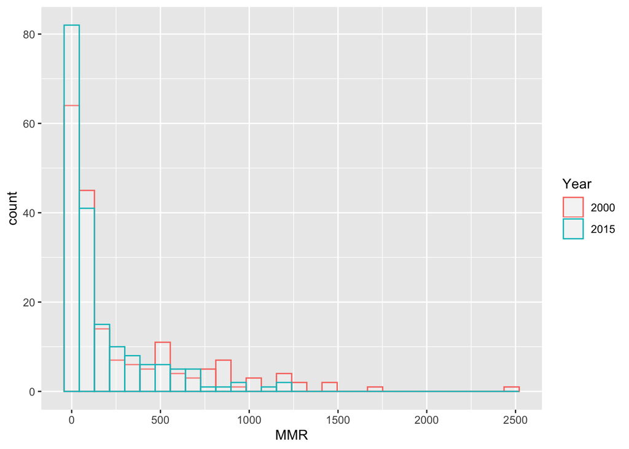

```r
data <- mmr_df %>% filter(Year==2000 | Year==2015) %>% select(MMR, Year)
data$Year <- as.factor(data$Year)

ggplot(data=data, aes(x=MMR, color=Year)) +
  geom_histogram(fill='white', alpha=0.2, position="identity") +
  scale_color_discrete(name="Year", labels=c(2000, 2015))
```

### Changes in Mortality by Country

Let’s see which countries have the most reduction in maternal deaths.

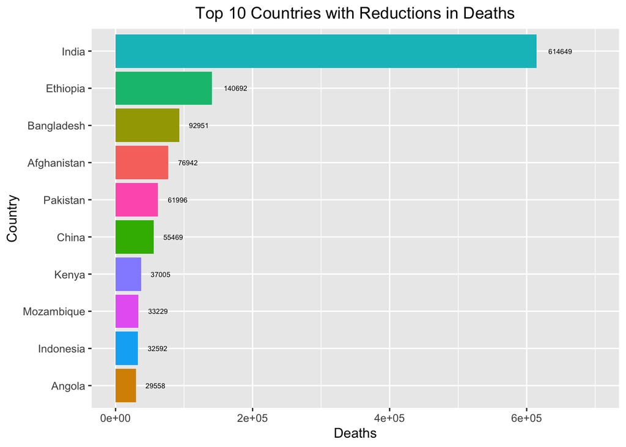

```r
# Group data by country and calculate the delta in deaths over the years
tbl <- mmr_df %>%
  group_by(Country) %>%
  summarize(delta = round(first(Deaths) - last(Deaths))) %>%
  arrange(desc(delta)) %>%
  drop_na()

# barplot
ggplot(tbl %>% top_n(10, delta), aes(x=reorder(Country, delta), y=delta, fill=Country)) +
  ggtitle("Top 10 Countries with Reductions in Deaths") +
  theme(plot.title = element_text(hjust = 0.5)) +
  geom_bar(position='dodge', stat="identity") +
  geom_text(aes(reorder(Country, delta), y=delta, label = round(delta)), size = 2, hjust = -0.5, vjust = 0.5 ) +
  scale_y_discrete(labels = comma, breaks=c(1000, 100000, 200000, 600000)) +
  ylim(c(0,700000)) +
  xlab('Country') +
  ylab('Deaths') +
  theme(legend.position = "none") +
  coord_flip()
```

… and those with increases in maternal deaths. Nigeria is clearly experiencing a crisis.

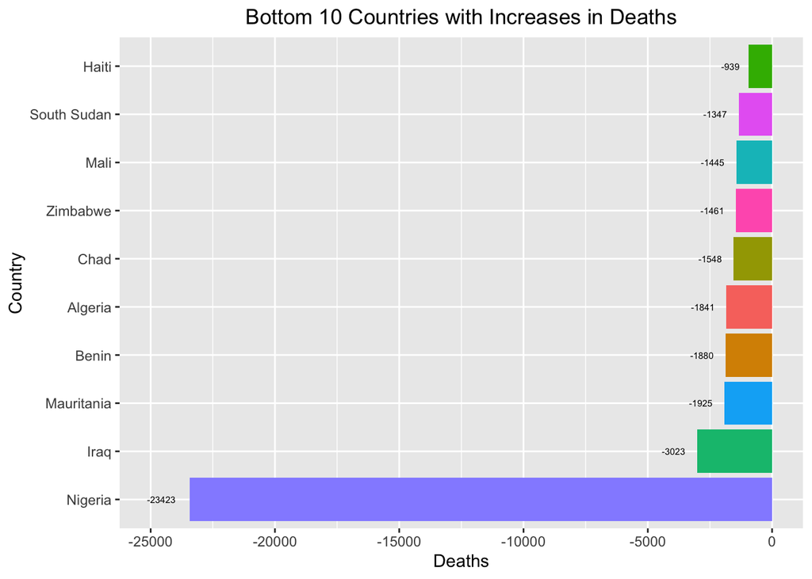

```r
# barplot
ggplot(tbl %>% top_n(-10, delta), aes(x=reorder(Country, delta), y=delta, fill=Country)) +
  ggtitle("Bottom 10 Countries with Increases in Deaths") +
  theme(plot.title = element_text(hjust = 0.5)) +
  geom_bar(position='dodge', stat="identity") +
  geom_text(aes(reorder(Country, delta), y=delta, label = round(delta)), size = 2, hjust = 1.5, vjust = 0.5 ) +
  scale_y_discrete(labels = comma, breaks=c(-30000, -20000, -1000)) +
  ylim(c(-25000,0)) +
  xlab('Country') +
  ylab('Deaths') +
  theme(legend.position = "none") +
  coord_flip()
```

```r
# Group data by country and calculate the delta in deaths over the years
mmr_df <- mmr_df %>%
  group_by(Country) %>%
  mutate(delta = Deaths - lag(Deaths, order_by=Year, default=first(Deaths)))
```

### Health Expenditures vs GDP

We see that generally, countries spend less than $4000 (PPP) adjusted dollars per person on health expenditures and as GDP increases, there is an increase in CHE. We some clear outliers with very high GDP countries spending very little and vice versa, countries with relatively low GDP spending reporting quite high CHE. While this is an interesting pattern, I suspect that CHE is not entriely reported nor being spent on the poorest population that might be more impacted by MMR. Unfortunaely, I don’t have the dataset to fully explore those questions.

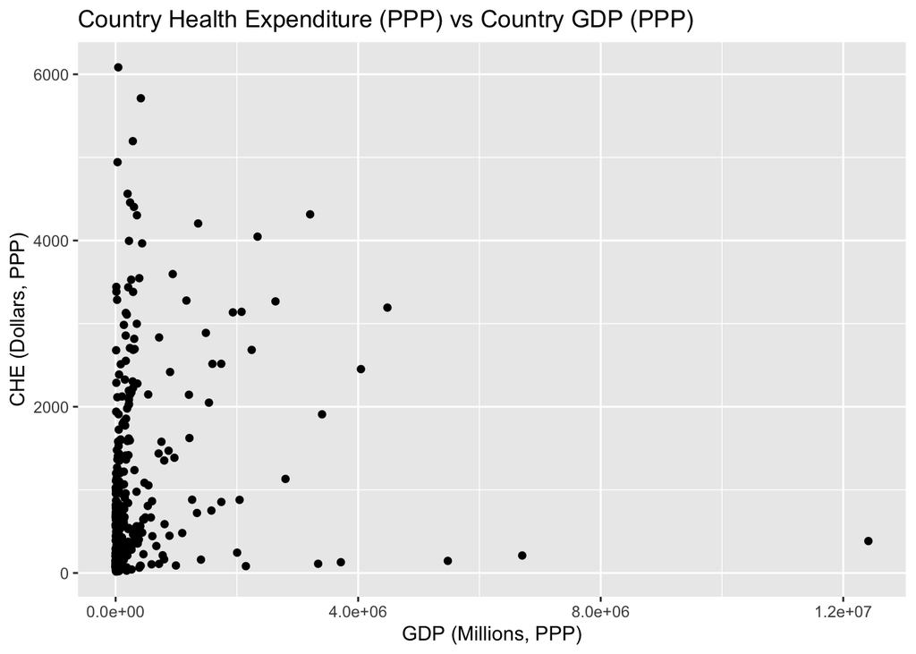

```r
ggplot(mmr_df, aes(GDP, CHE)) +
  geom_point() +
  labs(title='Country Health Expenditure (PPP) vs Country GDP (PPP)') +
  xlab('GDP (Millions, PPP)') +
  ylab('CHE (Dollars, PPP)')
```

### MMR vs CHE

We do see a pattern where higher reported health expenditures correlate with lower maternal mortality and inversely, those countries (and years) with lower CHE see higher MMR.

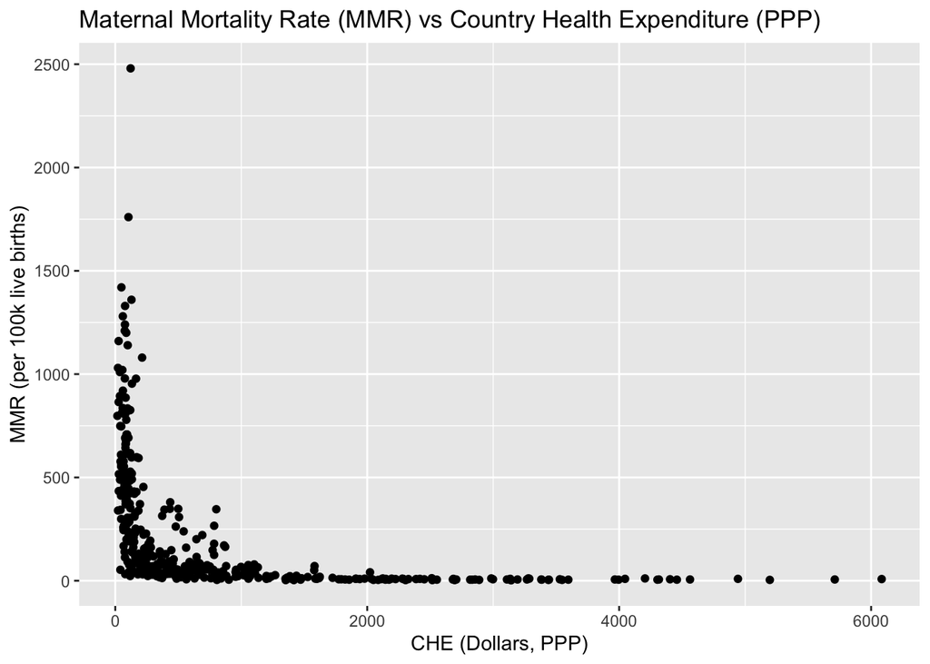

```r
ggplot(mmr_df, aes(CHE, MMR)) +
  geom_point() +
  labs(title='Maternal Mortality Rate (MMR) vs Country Health Expenditure (PPP)') +
  xlab('CHE (Dollars, PPP)') +
  ylab('MMR (per 100k live births)')
```

### Maternal Deaths vs CHE

The death count increases most dramatically with lower health expenditures and population impacts.

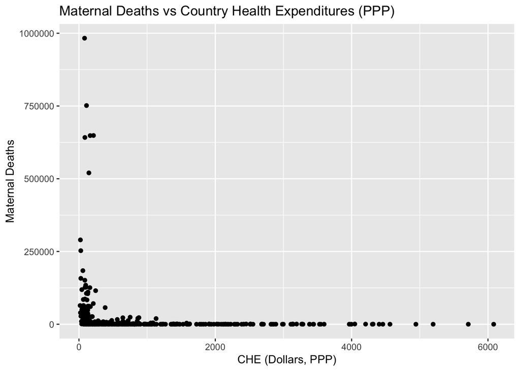

```r
ggplot(mmr_df, aes(CHE, Deaths)) +
  geom_point() +
  labs(title='Maternal Deaths vs Country Health Expenditures (PPP)') +
  xlab('CHE (Dollars, PPP)') +
  ylab('Maternal Deaths')
```

### MMR vs GDP

Generally the Maternal Mortality rate is higher with counties having lower GDP.

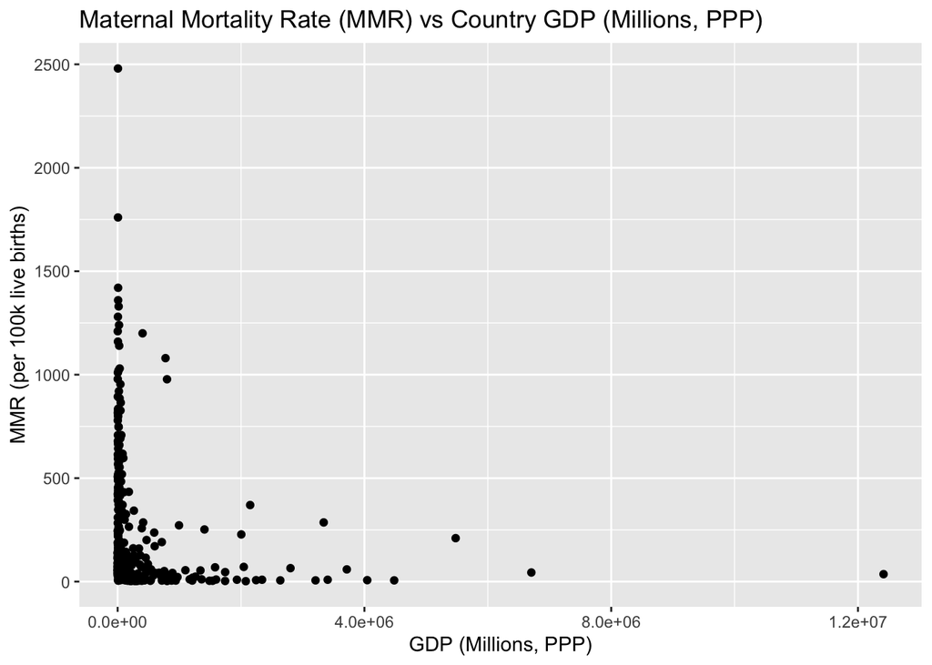

```r
ggplot(mmr_df, aes(GDP, MMR)) +
  geom_point() +
  labs(title='Maternal Mortality Rate (MMR) vs Country GDP (Millions, PPP)') +
  xlab('GDP (Millions, PPP)') +
  ylab('MMR (per 100k live births)')
```

### Skilled Attendants and MMR

While we don’t have many datapoints, there does appear to be a trend with lowered materal mortality when there is a higher percentage of births managed by a health professional. That said, a Skilled Attendant at birth may only be able to do so much … there may be affects earlier in pregnancy leading to mortality.

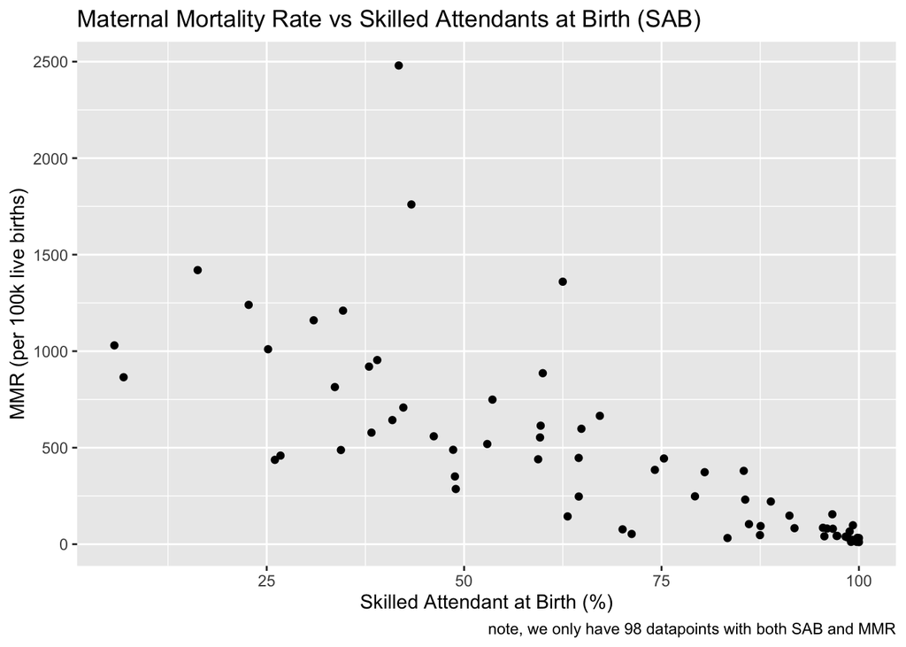

```r
ggplot(mmr_df %>% drop_na(), aes(SAB_Pct, MMR)) +
  geom_point() +
  labs(title='Maternal Mortality Rate vs Skilled Attendants at Birth (SAB)',
       caption='note, we only have 98 datapoints with both SAB and MMR')+
  xlab('Skilled Attendant at Birth (%)') +
  ylab('MMR (per 100k live births)')
```

### Skilled Attendants and Deaths

As with mortality rate, we generally see fewer reported deaths as the percent of births are handled by a trained health professional.

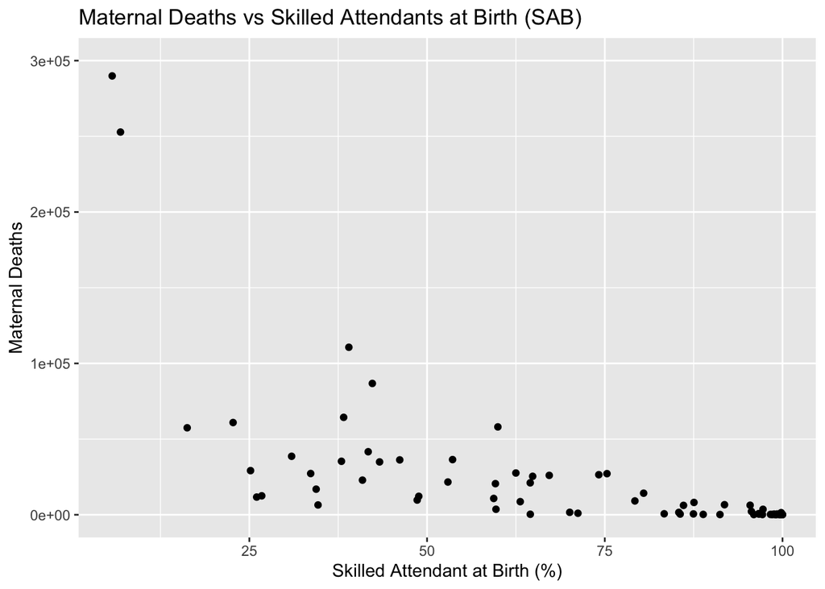

```r
ggplot(mmr_df %>% drop_na(), aes(SAB_Pct, Deaths)) +
  geom_point() +
  scale_y_continuous(labels = comma) +
  ylim(0, 300000) +
  labs(title='Maternal Deaths vs Skilled Attendants at Birth (SAB)') +
  xlab('Skilled Attendant at Birth (%)') +
  ylab('Maternal Deaths')
```

## Summary

I started this project with a single core dataset with MMR by country and year. As I tried to answer questions, I found I needed additional data which lead to chasing down populations, birthrates and country codes. Only then did I seek out the Skilled Attendants and Health Spending data to look for patterns. Worldwide, the reported maternal mortality rate has dropped by ~40% which broadly shows up in my histograms. While the overall mortality rate is decreasing, some countries are greatly improving (e.g. India) while others have more deaths (e.g. Nigeria). Looking at health spend, GDP and presence of Skilled Attendants during birth, the later had the most notable correlation, but data was scarce. The NGO I worked with was targeting training of health workers, and from this quick survey of data, that is likely a fruitful approach to the problem.

## References

- [World Health Expediture Database](http://apps.who.int/nha/database/ViewData/Indicators/en)
- [Trends in estimates of maternal mortality ratio (maternal deaths per 100,000 live births) 2000-2017 (September 2019)](https://data.unicef.org/wp-content/uploads/2015/11/MMR-trend-estimates-2000-2017_MMEIG-2.xlsx)
- [All adolescents maternal health indicators (July 2018)](https://data.unicef.org/wp-content/uploads/2018/07/maternal_health_adolescents_indicators_April-2016_250d599.xlsx)
- [WHO Health Expenditures by Country](http://apps.who.int/nha/database/ViewData/Indicators/en)
- [Birthrate Data by Country](http://api.worldbank.org/v2/en/indicator/SP.DYN.CBRT.IN?downloadformat=excel)
- List_of_countries_by_past_and_future_population
- [World ISO3 Country Codes](https://www.iban.com/country-codes)